# Part II - Factors affecting the Loan Status- Prosper Loan Data

## by Kazeem Fatai

## Investigation Overview

> About half of the loans are currently on with only about 30% completed. Only a few loans have the best risk score but a good percentage of all the loans have good risk rating. Most of the loans have their length to be 3 years. The variables listed above are the focus of this presentation and interestingly, have a relationhip with the interest rate and loan amount. The median of the interest rate decreases as the prosper score improves and lower interest rates are associated with Loans with better Prosper Ratings. This indicates the close relationship between the prosper score and prosper rating. A high percentage of loans whose term is 1 year are completed already. Firstly, a look at the distribution of these variables will help understand how each categorical and non categorical variables spread through out the entire dataset. Next, i aim to show how the ProsperRating and Score affects the interest rate. The status of the loan has some characteristics which i will be explaining in this slide deck.

## Dataset Overview

> This dataset contains 113937 samples of 21 variables. With different data types for the different variables, this data contains records for a loan Company - Prosper. Some of these records are but not limited to the interest rate, loan status, the risk score of each loan and information concerning the borrower.

## Loan Amount Distribution

> *The loan amount distribution shows the frequency of borrowers across the different loan amounts taken. It appears that most loan amouts are in the multiple of 5000 USD as there were spikes at these values on the plot*

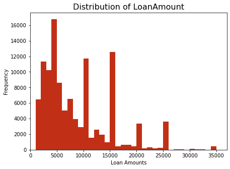

## Borrower Rate Distribution Across the Dataset

> It can be seen how values between 0.30% and 0.40% reached peak values but interest rate 0.1-0.2% also shows a very high frequency of loans. There are very few number of loans with very low interest rate.

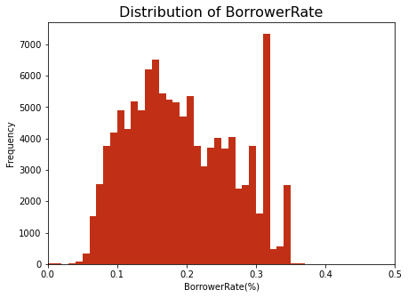

## The relationship between The Borrower Rate and Loan amount taken

> The Loan amount does not have a linear relationship with the interest rate as loans of the same amount have different interest rates Further investigation shows that the Prosper Rating has an impact on the interest rate as the best ratings get lower interest rates and the worst ratings get very high interest rate

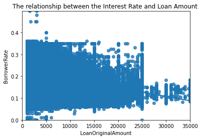

## Impact of Prosper Rating on The relationship between BorrowerRate and LoanAmount

> The Prosper Rating has an impact on the interest rate as the best ratings get lower interest rates and the worst ratings get very high interest rate

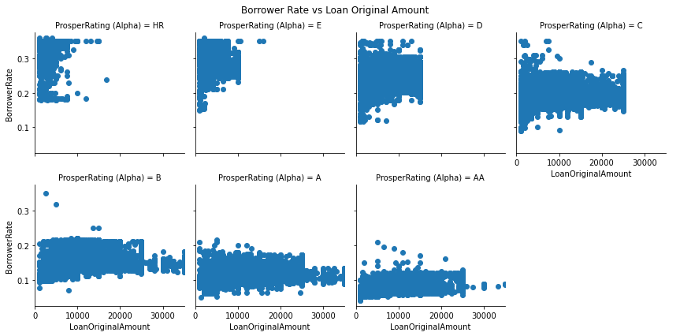